# ioslides With Two Columns (mostly failed tests)

10/17/2019

## Two-column Layout Using *CSS* Code

The formatting of *R Markdown* documents can be controlled using *CSS* code stored in a separate file. The file with *CSS* code should be either in the same directory as the *R Markdown* file, or in a sub-directory.

Below is an example of two-column layout using *CSS* code.  
The location of the break between columns is specified by the *CSS* style code in the file slides.css.  
The left column is 40%, and the right is 60% of the page width.

The left column contains *R* code that returns the summary of the *cars* data frame:

```r
> summary(cars)
```

The right column contains the output of the *R* code in the left column:

```
##      speed           dist
##  Min.   : 4.0   Min.   :  2
##  1st Qu.:12.0   1st Qu.: 26
##  Median :15.0   Median : 36
##  Mean   :15.4   Mean   : 43
##  3rd Qu.:19.0   3rd Qu.: 56
##  Max.   :25.0   Max.   :120
```

## Slide with *R* Code and Output in Two Columns

Left column contains *R* code that returns the summary of the *cars* data frame: This doesn’t work.

```r
> summary(cars)
```

Right column with extra copy of *R* output:

```
##      speed           dist
##  Min.   : 4.0   Min.   :  2
##  1st Qu.:12.0   1st Qu.: 26
##  Median :15.0   Median : 36
##  Mean   :15.4   Mean   : 43
##  3rd Qu.:19.0   3rd Qu.: 56
##  Max.   :25.0   Max.   :120
```

## Plots in Two-column Layout Without *CSS*

Example of two-column layout with a plot. But there’s no way to control the location of the content break between columns.

Plot the Normal probability density function:

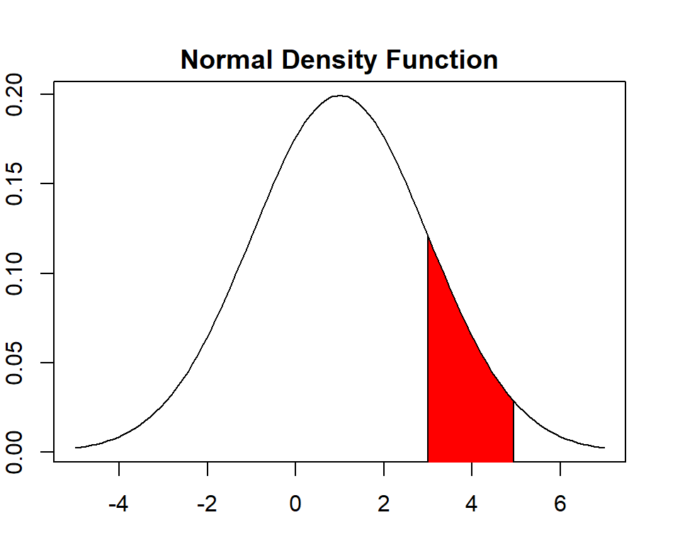

```r
> par(mar=c(2, 1, 2, 1))  # Set plot margins
> par(oma=c(1, 1, 1, 1))  # Set outer margins
> x_var <- seq(-5, 7, length=100)
> y_var <- dnorm(x_var, mean=1.0, sd=2.0)
> plot(x_var, y_var, type="l", lty="solid",
+      xlab="", ylab="")
> title(main="Normal Density Function", line=0.5)
> # Set shading range
> star_t <- 3; fin_ish <- 5
> # Set polygon base
> are_a <- ((x_var >= star_t) & (x_var <= fin_ish))
> # Draw shaded area
> polygon(c(star_t, x_var[are_a], fin_ish),
+         c(-1, y_var[are_a], -1), col="red")
```

## Slide with Multiple Columns Using alt *CSS* Code

This works, but even a small modification messes up the column breaks.

Left column with head of *mtcars* data frame:

```r
> head(mtcars, 6)
##                    mpg cyl disp  hp drat   wt qsec vs am gear carb
## Mazda RX4         21.0   6  160 110 3.90 2.62 16.5  0  1    4    4
## Mazda RX4 Wag     21.0   6  160 110 3.90 2.88 17.0  0  1    4    4
## Datsun 710        22.8   4  108  93 3.85 2.32 18.6  1  1    4    1
## Hornet 4 Drive    21.4   6  258 110 3.08 3.21 19.4  1  0    3    1
## Hornet Sportabout 18.7   8  360 175 3.15 3.44 17.0  0  0    3    2
## Valiant           18.1   6  225 105 2.76 3.46 20.2  1  0    3    1
```

Right column with tail of *mtcars* data frame:

```r
> tail(mtcars, 6)
##                 mpg cyl  disp  hp drat   wt qsec vs am gear carb
## Porsche 914-2  26.0   4 120.3  91 4.43 2.14 16.7  0  1    5    2
## Lotus Europa   30.4   4  95.1 113 3.77 1.51 16.9  1  1    5    2
## Ford Pantera L 15.8   8 351.0 264 4.22 3.17 14.5  0  1    5    4
## Ferrari Dino   19.7   6 145.0 175 3.62 2.77 15.5  0  1    5    6
## Maserati Bora  15.0   8 301.0 335 3.54 3.57 14.6  0  1    5    8
## Volvo 142E     21.4   4 121.0 109 4.11 2.78 18.6  1  1    4    2
```

## Another Slide with Multiple Columns Using alt *CSS* Code

This doesn’t work. The chunk option `eval = FALSE` is messing up the columns.

Left column with *R* code that returns the summary of the *iris* data frame:

```r
> summary(iris)
```

Right column with extra copy of *R* output:

```r
> summary(iris)
##   Sepal.Length   Sepal.Width    Petal.Length   Petal.Width        Species
##  Min.   :4.30   Min.   :2.00   Min.   :1.00   Min.   :0.1   setosa    :50
##  1st Qu.:5.10   1st Qu.:2.80   1st Qu.:1.60   1st Qu.:0.3   versicolor:50
##  Median :5.80   Median :3.00   Median :4.35   Median :1.3   virginica :50
##  Mean   :5.84   Mean   :3.06   Mean   :3.76   Mean   :1.2
##  3rd Qu.:6.40   3rd Qu.:3.30   3rd Qu.:5.10   3rd Qu.:1.8
##  Max.   :7.90   Max.   :4.40   Max.   :6.90   Max.   :2.5
```

## Slide with Multiple Columns Using alt *CSS* Code

**1** one  
**2** two  
more text  
more text  
more text  
**3** three  
**4** four  
**5** five  
**6** six  
more text  
more text  
more text  
**7** seven  
**8** eight  
more text  
more text  
more text  
**9** nine

## Slide with Two Columns

##### Left column:

[figure not shown]

##### Right column:

- Bullet 1
- Bullet 2
- Bullet 3

## Slide with Multiple Columns Using *CSS* Code

```
Left column's content

Right column's content
```

## Slide with R Code and Plot in Two Columns

*Ioslides* allow for creating slides with two columns, but it’s not possible to control where the second column starts. The second column starts only after the first column is fully filled with lines of content.

### First column with *R* code:

```r
> plot(cars)
```

empty lines to fill up the first column …  
…  
…  
…  
…  
…  
…  
…  
…

### Second column with plot:

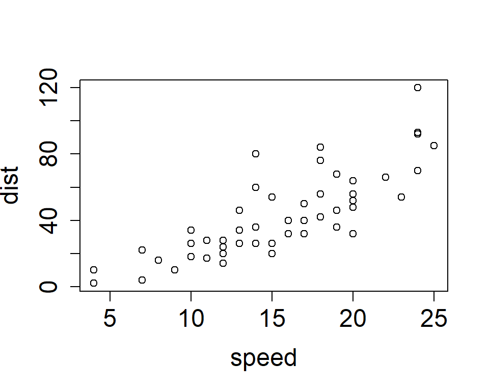

## Slide with R Code and Output in Two Columns

First column contains simple R code that returns the summary of the cars data frame:

```r
> summary(cars)
```

Second column contains the output of the code in the first column:

```
##      speed           dist
##  Min.   : 4.0   Min.   :  2
##  1st Qu.:12.0   1st Qu.: 26
##  Median :15.0   Median : 36
##  Mean   :15.4   Mean   : 43
##  3rd Qu.:19.0   3rd Qu.: 56
##  Max.   :25.0   Max.   :120
```